# Bellabeat_project

## Primer trabajo exploratorio de los Dataframes más grandes:

Hay dataframes con datos a nivel de minuto, se empieza por hacer un ETL de estos.

```r
print(" Estudio sueño ------------------- tamaño y columnas")
```

```
## [1] " Estudio sueño ------------------- tamaño y columnas"
```

```r
size_sum(sueno_minutos)
```

```
## [1] "[198,559 × 4]"
```

```r
sapply(sueno_minutos, class)
```

```
##          Id        date       value       logId
##   "numeric" "character"   "integer"   "numeric"
```

```r
cat("\n Estudio caminata ------------------- tamaño y columnas \n")
```

```
##
##  Estudio caminata ------------------- tamaño y columnas
```

```r
size_sum(caminata_minutos)
```

```
## [1] "[1,445,040 × 3]"
```

```r
sapply(caminata_minutos, class)
```

```
##             Id ActivityMinute          Steps
##      "numeric"    "character"      "integer"
```

```r
cat("\n Estudio ejercicios de intensidad ------------------- tamaño y columnas \n")
```

```
##
##  Estudio ejercicios de intensidad ------------------- tamaño y columnas
```

```r
size_sum(intensidad_minutos)
```

```
## [1] "[1,445,040 × 3]"
```

```r
sapply(intensidad_minutos, class)
```

```
##             Id ActivityMinute      Intensity
##      "numeric"    "character"      "integer"
```

```r
cat("\n Estudio frecuencia cardiaca ------------------- tamaño y columnas \n")
```

```
##
##  Estudio frecuencia cardiaca ------------------- tamaño y columnas
```

```r
size_sum(frecuencia_cardiaca)
```

```
## [1] "[1,154,681 × 3]"
```

```r
sapply(frecuencia_cardiaca, class)
```

```
##          Id        Time       Value
##   "numeric" "character"   "integer"
```

```r
cat("\n Estudio equivalencia metabólica ------------------- tamaño y columnas \n")
```

```
##
##  Estudio equivalencia metabólica ------------------- tamaño y columnas
```

```r
size_sum(metabolica_minutos)
```

```
## [1] "[1,445,040 × 3]"
```

```r
sapply(metabolica_minutos, class)
```

```
##             Id ActivityMinute           METs
##      "numeric"    "character"      "integer"
```

```r
cat("\n Estudio calorias por minuto ------------------- tamaño y columnas \n")
```

```
##
##  Estudio calorias por minuto ------------------- tamaño y columnas
```

```r
size_sum(calorias_minuto)
```

```
## [1] "[1,445,040 × 3]"
```

```r
sapply(calorias_minuto, class)
```

```
##             Id ActivityMinute       Calories
##      "numeric"    "character"      "numeric"
```

## Cuantas personas hay en cada data frame de datos por minuto?

```r
cat("Estudio de sueño: ", n_distinct(sueno_minutos$Id), "personas \n")
```

```
## Estudio de sueño:  23 personas
```

```r
cat("Medición de caminata: ", n_distinct(caminata_minutos$Id), "personas \n")
```

```
## Medición de caminata:  34 personas
```

```r
cat("Estudio de actividad intensa: ", n_distinct(intensidad_minutos$Id), " personas\n")
```

```
## Estudio de actividad intensa:  34  personas
```

```r
cat("Estudio de actividad metabolica (METs): ", n_distinct(metabolica_minutos$Id), "personas \n")
```

```
## Estudio de actividad metabolica (METs):  34 personas
```

```r
cat("Estudio de frecuencia cardiaca: ", n_distinct(frecuencia_cardiaca$Id), "personas \n")
```

```
## Estudio de frecuencia cardiaca:  14 personas
```

```r
cat("Estudio de calorias por minuto: ", n_distinct(calorias_minuto$Id), "personas \n")
```

```
## Estudio de calorias por minuto:  34 personas
```

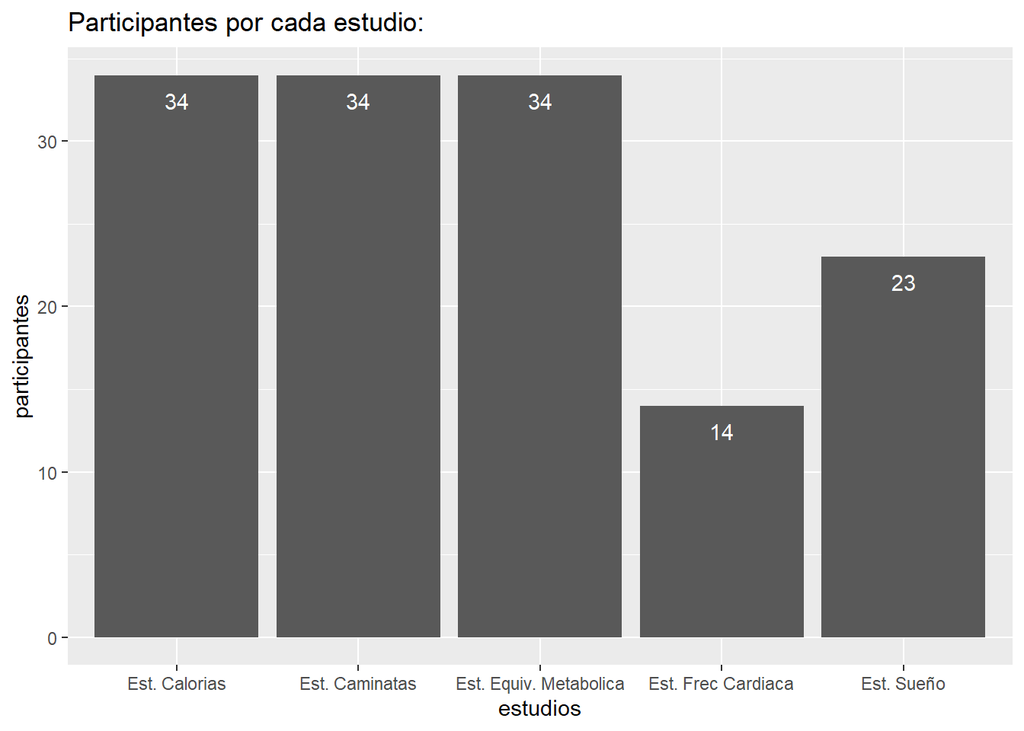

```r
estudios <- c("Est. Sueño", "Est. Caminatas", "Est. Frec Cardiaca", "Est. Equiv. Metabolica", "Est. Calorias" )
participantes <- c(n_distinct(sueno_minutos$Id), n_distinct(caminata_minutos$Id), n_distinct(frecuencia_cardiaca$Id), n_distinct(metabolica_minutos$Id), n_distinct(calorias_minuto$Id))

df_est1 <- data.frame(estudios, participantes)

participantes_est_minuto <- ggplot(data = df_est1, aes(x=estudios, y=participantes)) + geom_bar(stat = "identity") + labs(title = "Participantes por cada estudio: ") + geom_text(aes(label = participantes), vjust = 2, colour = "white")


participantes_est_minuto
```

## Primer resultado exploratorio

Con esta infomación se decide descartar el estudio de Frecuencia cardiaca, por riesgo de sesgo que significa esta cantidad de muestras. Y se estudiará el resto de los estudios. El estudio del sueño se harán algunas revisiones para agregar o descartar.

```r
# se procede a unir los Dataframes

df_actividad_largo = full_join(caminata_minutos, intensidad_minutos, by=c("Id", "ActivityMinute"))
df_actividad_largo = full_join(df_actividad_largo, metabolica_minutos, by=c("Id", "ActivityMinute"))
df_actividad_largo = full_join(df_actividad_largo, calorias_minuto, by=c("Id", "ActivityMinute"))

str(df_actividad_largo)
```

```
## 'data.frame':    1445040 obs. of  6 variables:
##  $ Id            : num  1.5e+09 1.5e+09 1.5e+09 1.5e+09 1.5e+09 ...
##  $ ActivityMinute: chr  "3/12/2016 12:00:00 AM" "3/12/2016 12:01:00 AM" "3/12/2016 12:02:00 AM" "3/12/2016 12:03:00 AM" ...
##  $ Steps         : int  0 0 0 0 0 0 0 0 0 0 ...
##  $ Intensity     : int  0 0 0 0 0 0 0 0 0 0 ...
##  $ METs          : int  10 10 10 10 10 10 10 10 10 10 ...
##  $ Calories      : num  0.797 0.797 0.797 0.797 0.797 ...
```

```r
# Contar los NA por columna
na_por_columna <- sapply(df_actividad_largo, function(x) sum(is.na(x)))

# Mostrar el resultado
print("Ver si tengo valores nulo en alguna columna")
```

```
## [1] "Ver si tengo valores nulo en alguna columna"
```

```r
print(na_por_columna)
```

```
##             Id ActivityMinute          Steps      Intensity           METs
##              0              0              0              0              0
##       Calories
##              0
```

```r
# cambio el formato de fecha

df_actividad_largo$ActivityMinute = as.POSIXct(df_actividad_largo$ActivityMinute, format="%m/%d/%Y %I:%M:%S  %p", tz = "UTC")
print(head(df_actividad_largo))
```

```
##           Id      ActivityMinute Steps Intensity METs Calories
## 1 1503960366 2016-03-12 00:00:00     0         0   10   0.7973
## 2 1503960366 2016-03-12 00:01:00     0         0   10   0.7973
## 3 1503960366 2016-03-12 00:02:00     0         0   10   0.7973
## 4 1503960366 2016-03-12 00:03:00     0         0   10   0.7973
## 5 1503960366 2016-03-12 00:04:00     0         0   10   0.7973
## 6 1503960366 2016-03-12 00:05:00     0         0   10   0.7973
```

```r
df_actividad_largo$Time <- format(df_actividad_largo$ActivityMinute, format = "%H")
df_actividad_largo$Date <- format(df_actividad_largo$ActivityMinute, format = "%Y/%m/%d")
```

```r
df_actividad_largo$Time <- as.integer(df_actividad_largo$Time)

#separate(df_actividad_largo, ActivityMinute, into = c("Date", "Time"), sep = " ")

summary(df_actividad_largo)
```

```
##        Id            ActivityMinute                      Steps
##  Min.   :1.504e+09   Min.   :2016-03-12 00:00:00.0   Min.   :  0.00
##  1st Qu.:2.347e+09   1st Qu.:2016-03-19 14:27:00.0   1st Qu.:  0.00
##  Median :4.559e+09   Median :2016-03-27 04:54:00.0   Median :  0.00
##  Mean   :4.889e+09   Mean   :2016-03-27 06:16:53.2   Mean   :  4.77
##  3rd Qu.:6.962e+09   3rd Qu.:2016-04-03 20:11:00.0   3rd Qu.:  0.00
##  Max.   :8.878e+09   Max.   :2016-04-12 10:59:00.0   Max.   :204.00
##    Intensity           METs           Calories            Time
##  Min.   :0.0000   Min.   :  0.00   Min.   : 0.0000   Min.   : 0.00
##  1st Qu.:0.0000   1st Qu.: 10.00   1st Qu.: 0.9357   1st Qu.: 5.00
##  Median :0.0000   Median : 10.00   Median : 1.2176   Median :11.00
##  Mean   :0.1804   Mean   : 14.24   Mean   : 1.5713   Mean   :11.42
##  3rd Qu.:0.0000   3rd Qu.: 11.00   3rd Qu.: 1.4060   3rd Qu.:17.00
##  Max.   :3.0000   Max.   :189.00   Max.   :23.0126   Max.   :23.00
##      Date
##  Length:1445040
##  Class :character
##  Mode  :character
##
##
##
```

```r
head(df_actividad_largo)
```

```
##           Id      ActivityMinute Steps Intensity METs Calories Time       Date
## 1 1503960366 2016-03-12 00:00:00     0         0   10   0.7973    0 2016/03/12
## 2 1503960366 2016-03-12 00:01:00     0         0   10   0.7973    0 2016/03/12
## 3 1503960366 2016-03-12 00:02:00     0         0   10   0.7973    0 2016/03/12
## 4 1503960366 2016-03-12 00:03:00     0         0   10   0.7973    0 2016/03/12
## 5 1503960366 2016-03-12 00:04:00     0         0   10   0.7973    0 2016/03/12
## 6 1503960366 2016-03-12 00:05:00     0         0   10   0.7973    0 2016/03/12
```

## Actividad diaria de los participantes.

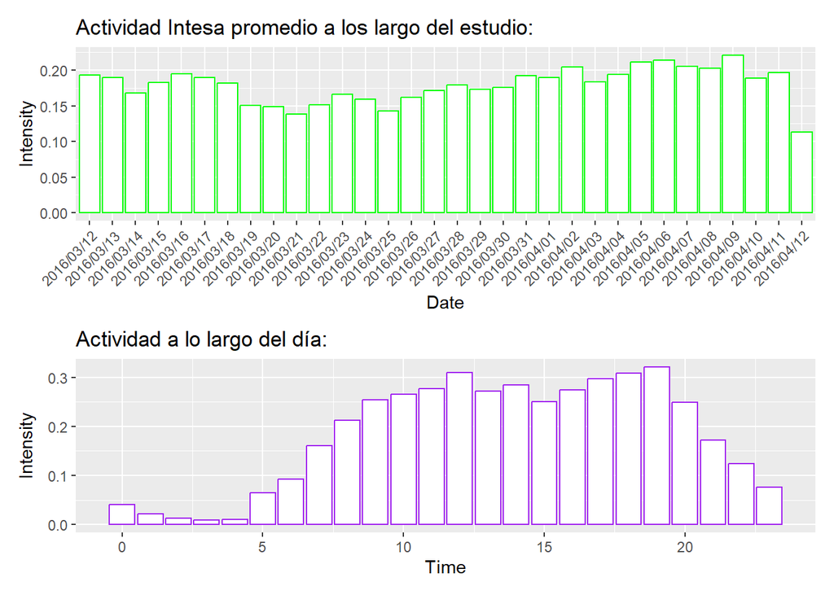

```r
actividad_x_fecha <- df_actividad_largo %>% group_by(Date) %>%
  summarise( Intensity = mean(Intensity),
             Steps = mean(Steps),
             METs = mean(METs),
             Calories = mean(Calories))

actividad_x_fecha1 <-  actividad_x_fecha %>% ggplot(., aes(x= Date, y= Intensity)) + geom_bar(stat = "identity", color = "green", fill = "white") + labs(title = "Actividad Intesa promedio a los largo del estudio: ") + theme(axis.text.x = element_text(angle = 45, hjust = 1))

actividad_x_hora <- df_actividad_largo %>% group_by(Time) %>%
  summarise( Intensity = mean(Intensity),
             Steps = mean(Steps),
             METs = mean(METs),
             Calories = mean(Calories))

actividad_x_hora1 <-  actividad_x_hora %>% ggplot( aes(x= Time, y= Intensity)) + geom_bar(stat = "identity", color = "purple", fill = "white") + labs(title = "Actividad a lo largo del día: ")

actividad_x_fecha1 / actividad_x_hora1
```

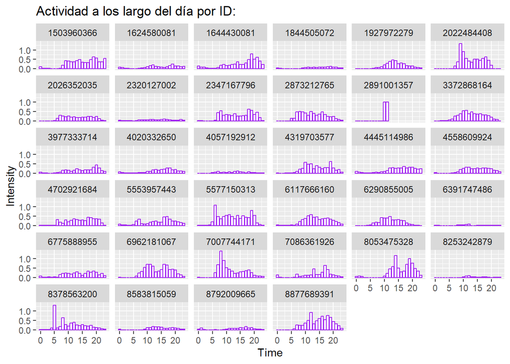

```r
actividad_x_hora2 <- df_actividad_largo %>% group_by(Time, Id) %>%
  summarise( Intensity = mean(Intensity, na.rm = TRUE), .groups = "drop")

actividad_x_hora3 <-  actividad_x_hora2 %>% ggplot( aes(x= Time, y= Intensity, color= Id)) + geom_bar(stat = "identity", color = "purple", fill = "white") + facet_wrap(~Id) +labs(title = "Actividad a los largo del día por ID: ")

actividad_x_hora3
```

Con este grafico vemos la intensidad de actividad que tiene ID por día.

## Vemos la cantidad de días que participaron los diferentes ID:

```r
dias_participa <- df_actividad_largo %>% select(., Id, Date) %>% unique()

table(dias_participa$Id)
```

```
##
## 1503960366 1624580081 1644430081 1844505072 1927972279 2022484408 2026352035
##         31         32         30         32         32         32         32
## 2320127002 2347167796 2873212765 2891001357 3372868164 3977333714 4020332650
##         32         32         31          1         30         32         32
## 4057192912 4319703577 4445114986 4558609924 4702921684 5553957443 5577150313
##         32         28         32         32         31         32         31
## 6117666160 6290855005 6391747486 6775888955 6962181067 7007744171 7086361926
##         29         22         29         29         32         32         32
## 8053475328 8253242879 8378563200 8583815059 8792009665 8877689391
##         32         31         32         28         32         32
```

## Correlatividad de variables

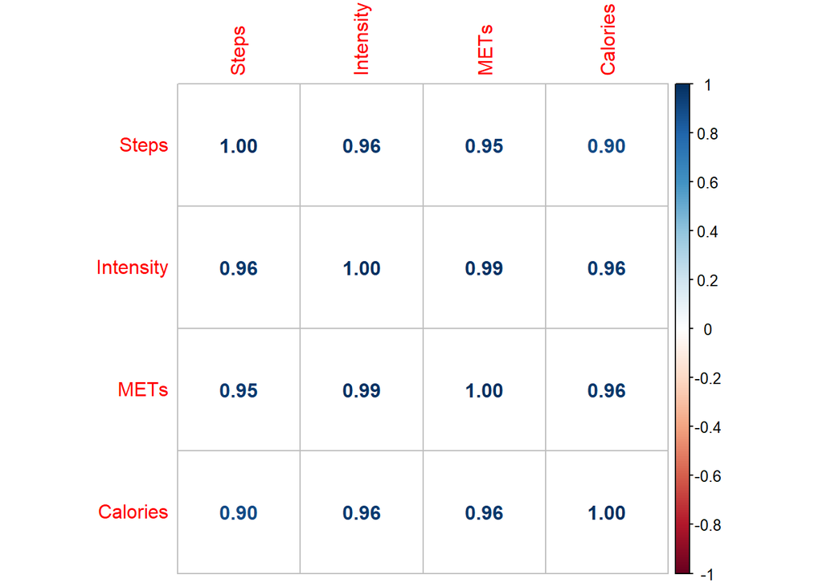

```r
#install.packages("corrplot")
library(corrplot)
correlatividad_act <- actividad_x_fecha %>% select(., Steps, Intensity, METs, Calories) %>% cor() %>% corrplot(., method = "number")
```

```r
correlatividad_act
```

```
## $corr
##               Steps Intensity      METs  Calories
## Steps     1.0000000 0.9637553 0.9546705 0.8960504
## Intensity 0.9637553 1.0000000 0.9898916 0.9562345
## METs      0.9546705 0.9898916 1.0000000 0.9608530
## Calories  0.8960504 0.9562345 0.9608530 1.0000000
##
## $corrPos
##        xName     yName x y      corr
## 1      Steps     Steps 1 4 1.0000000
## 2      Steps Intensity 1 3 0.9637553
## 3      Steps      METs 1 2 0.9546705
## 4      Steps  Calories 1 1 0.8960504
## 5  Intensity     Steps 2 4 0.9637553
## 6  Intensity Intensity 2 3 1.0000000
## 7  Intensity      METs 2 2 0.9898916
## 8  Intensity  Calories 2 1 0.9562345
## 9       METs     Steps 3 4 0.9546705
## 10      METs Intensity 3 3 0.9898916
## 11      METs      METs 3 2 1.0000000
## 12      METs  Calories 3 1 0.9608530
## 13  Calories     Steps 4 4 0.8960504
## 14  Calories Intensity 4 3 0.9562345
## 15  Calories      METs 4 2 0.9608530
## 16  Calories  Calories 4 1 1.0000000
##
## $arg
## $arg$type
## [1] "full"
```

Todas las variables están estrechamente correlacionadas.

## Teoria, calcular las horas de Sueño.

Creo que si el dispositivo en todo momento envía un status, se puede calcular las horas de sueño de los participantes que falta, por diferencia (minutos al dia - minutos activo = minutos de sueño) para eso hago el siguiente analisís:

```r
tail(sueno_minutos)
```

```
##                Id                date value       logId
## 198554 8792009665 4/9/2016 6:37:00 PM     1 11357751881
## 198555 8792009665 4/9/2016 6:38:00 PM     1 11357751881
## 198556 8792009665 4/9/2016 6:39:00 PM     1 11357751881
## 198557 8792009665 4/9/2016 6:40:00 PM     1 11357751881
## 198558 8792009665 4/9/2016 6:41:00 PM     1 11357751881
## 198559 8792009665 4/9/2016 6:42:00 PM     1 11357751881
```

```r
# prueba sueño
summary(sueno_minutos)
```

```
##        Id                date               value           logId
##  Min.   :1.504e+09   Length:198559      Min.   :1.000   Min.   :1.110e+10
##  1st Qu.:2.347e+09   Class :character   1st Qu.:1.000   1st Qu.:1.117e+10
##  Median :4.703e+09   Mode  :character   Median :1.000   Median :1.124e+10
##  Mean   :4.824e+09                      Mean   :1.086   Mean   :1.124e+10
##  3rd Qu.:6.776e+09                      3rd Qu.:1.000   3rd Qu.:1.131e+10
##  Max.   :8.792e+09                      Max.   :3.000   Max.   :1.137e+10
```

```r
# creo un datafame nuevo para no insertar NA en el original df_actividad_largo
sueno_minutos <- sueno_minutos %>% rename(.,ActivityMinute = "date")

sueno_minutos$ActivityMinute = as.POSIXct(sueno_minutos$ActivityMinute, format="%m/%d/%Y %I:%M:%S %p", tz = "UTC")
```

```r
ver_sueno <- full_join(df_actividad_largo, sueno_minutos, by = c("Id", "ActivityMinute"))
print("Si hay un registro por minuto de cada usuario deberiamos tener la misma cantidad de repeticiones por usuario")
```

```
## [1] "Si hay un registro por minuto de cada usuario deberiamos tener la misma cantidad de repeticiones por usuario"
```

```r
table(ver_sueno$Id)
```

```
##
## 1503960366 1624580081 1644430081 1844505072 1927972279 2022484408 2026352035
##      48013      45300      42000      45060      47802      45300      48008
## 2320127002 2347167796 2873212765 2891001357 3372868164 3977333714 4020332650
##      45300      47979      44400        720      42660      48397      46371
## 4057192912 4319703577 4445114986 4558609924 4702921684 5553957443 5577150313
##      45000      48711      49626      45322      50769      53143      52326
## 6117666160 6290855005 6391747486 6775888955 6962181067 7007744171 7086361926
##      49340      31260      40500      42064      48429      45345      47755
## 8053475328 8253242879 8378563200 8583815059 8792009665 8877689391
##      45240      44400      51339      39960      46655      45180
```

la mayoria de las personas tienen alrededor de 46.000 registros lo que si dividimos por la cantidad de minutos que tiene el día 1440 minutos, participaron 32 días.

### Se descarta la teoria de poder agregar el valor de los minutos de sueño, debido a que los números son muy dispares.

Se refresca los archivos dentro de nuestro dataset.

```r
print(nombre_y_tamaño)
```

```
##                                Nombre Tamaño
## 1            dailyActivity_merged.csv     NA
## 2        heartrate_seconds_merged.csv     NA
## 3           hourlyCalories_merged.csv     NA
## 4        hourlyIntensities_merged.csv     NA
## 5              hourlySteps_merged.csv     NA
## 6     minuteCaloriesNarrow_merged.csv     NA
## 7  minuteIntensitiesNarrow_merged.csv     NA
## 8         minuteMETsNarrow_merged.csv     NA
## 9              minuteSleep_merged.csv     NA
## 10       minuteStepsNarrow_merged.csv     NA
## 11           weightLogInfo_merged.csv     NA
```

Veo el final del dataframe para ver su estructura

```r
actividad_diaria <- read.csv("fitbit_data/dailyActivity_merged.csv")
calorias_hora <- read.csv("fitbit_data/hourlyCalories_merged.csv")
intensidad_hora <- read.csv("fitbit_data/hourlyIntensities_merged.csv")
caminata_hora <- read.csv("fitbit_data/hourlySteps_merged.csv")

print(tail(actividad_diaria))
```

```
##             Id ActivityDate TotalSteps TotalDistance TrackerDistance
## 452 8877689391     4/7/2016      10910          8.42            8.42
## 453 8877689391     4/8/2016      23014         20.39           20.39
## 454 8877689391     4/9/2016      16470          8.07            8.07
## 455 8877689391    4/10/2016      28497         27.53           27.53
## 456 8877689391    4/11/2016      10622          8.06            8.06
## 457 8877689391    4/12/2016       2350          1.78            1.78
##     LoggedActivitiesDistance VeryActiveDistance ModeratelyActiveDistance
## 452                        0               2.96                     0.39
## 453                        0              11.10                     0.63
## 454                        0               0.00                     0.02
## 455                        0              21.92                     1.12
## 456                        0               1.47                     0.15
## 457                        0               0.00                     0.00
##     LightActiveDistance SedentaryActiveDistance VeryActiveMinutes
## 452                5.03                    0.00                32
## 453                8.62                    0.00                70
## 454                8.02                    0.00                90
## 455                4.46                    0.00               128
## 456                6.37                    0.01                18
## 457                1.78                    0.00                 0
##     FairlyActiveMinutes LightlyActiveMinutes SedentaryMinutes Calories
## 452                  11                  212             1185     2947
## 453                  29                  359              982     4196
## 454                   9                  289             1052     3841
## 455                  46                  211             1055     4526
## 456                   7                  225             1190     2820
## 457                   0                   58              531      938
```

Realizo un resumen de los valores:

```r
summary(actividad_diaria)
```

```
##        Id            ActivityDate         TotalSteps    TotalDistance
##  Min.   :1.504e+09   Length:457         Min.   :    0   Min.   : 0.000
##  1st Qu.:2.347e+09   Class :character   1st Qu.: 1988   1st Qu.: 1.410
##  Median :4.057e+09   Mode  :character   Median : 5986   Median : 4.090
##  Mean   :4.629e+09                      Mean   : 6547   Mean   : 4.664
##  3rd Qu.:6.392e+09                      3rd Qu.:10198   3rd Qu.: 7.160
##  Max.   :8.878e+09                      Max.   :28497   Max.   :27.530
##  TrackerDistance LoggedActivitiesDistance VeryActiveDistance
##  Min.   : 0.00   Min.   :0.0000           Min.   : 0.000
##  1st Qu.: 1.28   1st Qu.:0.0000           1st Qu.: 0.000
##  Median : 4.09   Median :0.0000           Median : 0.000
##  Mean   : 4.61   Mean   :0.1794           Mean   : 1.181
##  3rd Qu.: 7.11   3rd Qu.:0.0000           3rd Qu.: 1.310
##  Max.   :27.53   Max.   :6.7271           Max.   :21.920
##  ModeratelyActiveDistance LightActiveDistance SedentaryActiveDistance
##  Min.   :0.0000           Min.   : 0.00       Min.   :0.000000
##  1st Qu.:0.0000           1st Qu.: 0.87       1st Qu.:0.000000
##  Median :0.0200           Median : 2.93       Median :0.000000
##  Mean   :0.4786           Mean   : 2.89       Mean   :0.001904
##  3rd Qu.:0.6700           3rd Qu.: 4.46       3rd Qu.:0.000000
##  Max.   :6.4000           Max.   :12.51       Max.   :0.100000
##  VeryActiveMinutes FairlyActiveMinutes LightlyActiveMinutes SedentaryMinutes
##  Min.   :  0.00    Min.   :  0.00      Min.   :  0.0        Min.   :  32.0
##  1st Qu.:  0.00    1st Qu.:  0.00      1st Qu.: 64.0        1st Qu.: 728.0
##  Median :  0.00    Median :  1.00      Median :181.0        Median :1057.0
##  Mean   : 16.62    Mean   : 13.07      Mean   :170.1        Mean   : 995.3
##  3rd Qu.: 25.00    3rd Qu.: 16.00      3rd Qu.:257.0        3rd Qu.:1285.0
##  Max.   :202.00    Max.   :660.00      Max.   :720.0        Max.   :1440.0
##     Calories
##  Min.   :   0
##  1st Qu.:1776
##  Median :2062
##  Mean   :2189
##  3rd Qu.:2667
##  Max.   :4562
```

Reviso las estructura de los ultimos archivos.

```r
print(" Estudio calorias hora ------------------- tamaño y columnas")
```

```
## [1] " Estudio calorias hora ------------------- tamaño y columnas"
```

```r
size_sum(calorias_hora)
```

```
## [1] "[24,084 × 3]"
```

```r
sapply(calorias_hora, class)
```

```
##           Id ActivityHour     Calories
##    "numeric"  "character"    "integer"
```

```r
cat("\n Estudio caminata hora ------------------- tamaño y columnas \n")
```

```
##
##  Estudio caminata hora ------------------- tamaño y columnas
```

```r
size_sum(caminata_hora)
```

```
## [1] "[24,084 × 3]"
```

```r
sapply(caminata_hora, class)
```

```
##           Id ActivityHour    StepTotal
##    "numeric"  "character"    "integer"
```

```r
cat("\n Estudio ejercicios intensidad hora ------------------- tamaño y columnas \n")
```

```
##
##  Estudio ejercicios intensidad hora ------------------- tamaño y columnas
```

```r
size_sum(intensidad_hora)
```

```
## [1] "[24,084 × 4]"
```

```r
sapply(intensidad_hora, class)
```

```
##               Id     ActivityHour   TotalIntensity AverageIntensity
##        "numeric"      "character"        "integer"        "numeric"
```

# Segmentar o Clusterizar perfiles.

El Dataframe más completo es el de Actividad Diaria.

Vamos a clasterizar los ID por comportamiento:

```r
names(actividad_diaria)
```

```
##  [1] "Id"                       "ActivityDate"
##  [3] "TotalSteps"               "TotalDistance"
##  [5] "TrackerDistance"          "LoggedActivitiesDistance"
##  [7] "VeryActiveDistance"       "ModeratelyActiveDistance"
##  [9] "LightActiveDistance"      "SedentaryActiveDistance"
## [11] "VeryActiveMinutes"        "FairlyActiveMinutes"
## [13] "LightlyActiveMinutes"     "SedentaryMinutes"
## [15] "Calories"
```

```r
df_actividad_x_id <- actividad_diaria %>% group_by(Id)  %>%
  summarise(
    MinutosMuyActivo = mean(VeryActiveMinutes),
    MinutosPocaAct = mean(LightlyActiveMinutes),
    MinutoSedentario = mean(SedentaryMinutes)
  )

df_actividad_x_id$Id <- as.factor(df_actividad_x_id$Id)

str(df_actividad_x_id)
```

```
## tibble [35 × 4] (S3: tbl_df/tbl/data.frame)
##  $ Id              : Factor w/ 35 levels "1503960366","1624580081",..: 1 2 3 4 5 6 7 8 9 10 ...
##  $ MinutosMuyActivo: num [1:35] 35.842 0.737 14.8 0.75 0 ...
##  $ MinutosPocaAct  : num [1:35] 228 121 228 158 112 ...
##  $ MinutoSedentario: num [1:35] 810 1278 1034 1035 953 ...
```

```r
# Contar los NA por columna
na_por_columna1 <- sapply(df_actividad_x_id , function(x) sum(is.na(x)))

# Mostrar el resultado
print("Ver si tengo valores nulo en alguna columna")
```

```
## [1] "Ver si tengo valores nulo en alguna columna"
```

```r
print(na_por_columna1)
```

```
##               Id MinutosMuyActivo   MinutosPocaAct MinutoSedentario
##                0                0                0                0
```

Descripción de cantidad de días que cada sujeto realizo cada tipo de actividad.

```r
df_cantidadDiaAct <- actividad_diaria %>% group_by(Id)  %>%
  summarise(
    MinutosMuyActivo = sum(VeryActiveMinutes != 0, na.rm = TRUE),
    MinutosPocaAct = sum(LightlyActiveMinutes != 0, na.rm = TRUE),
    MinutoSedentario = sum(SedentaryMinutes != 0, na.rm = TRUE),
  )

df_cantidadDiaAct$Id <- as.factor(df_cantidadDiaAct$Id)

str(df_cantidadDiaAct)
```

```
## tibble [35 × 4] (S3: tbl_df/tbl/data.frame)
##  $ Id              : Factor w/ 35 levels "1503960366","1624580081",..: 1 2 3 4 5 6 7 8 9 10 ...
##  $ MinutosMuyActivo: int [1:35] 18 2 8 1 0 11 0 2 11 5 ...
##  $ MinutosPocaAct  : int [1:35] 19 19 10 9 12 12 12 8 14 11 ...
##  $ MinutoSedentario: int [1:35] 19 19 10 12 12 12 12 12 15 12 ...
```

Se clusteriza los perfiles por el promedio de actividad diario de cada participante del estudio.

```r
#install.packages("cluster")
library(cluster)
#install.packages("factoextra")
library(factoextra)
df <- df_actividad_x_id %>%
  mutate(across(c(MinutosMuyActivo, MinutosPocaAct, MinutoSedentario), scale))

set.seed(123)  # Para reproducibilidad
kmeans_result <- kmeans(df %>% select(MinutosMuyActivo, MinutosPocaAct, MinutoSedentario), centers = 3)  # Cambia '3' por el número de clusters deseado

df$cluster <- kmeans_result$cluster
```

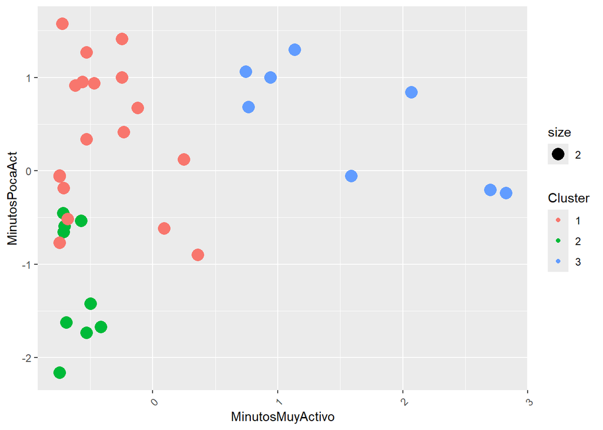

```r
ggplot(df, aes(x = MinutosMuyActivo, y= MinutosPocaAct, color = as.factor(cluster))) +
  geom_point(aes(size = 2)) +
  labs(color = "Cluster") + theme(axis.text.x = element_text(angle = 45, hjust = 1))
```

## Ver metricas por metodo del Codo

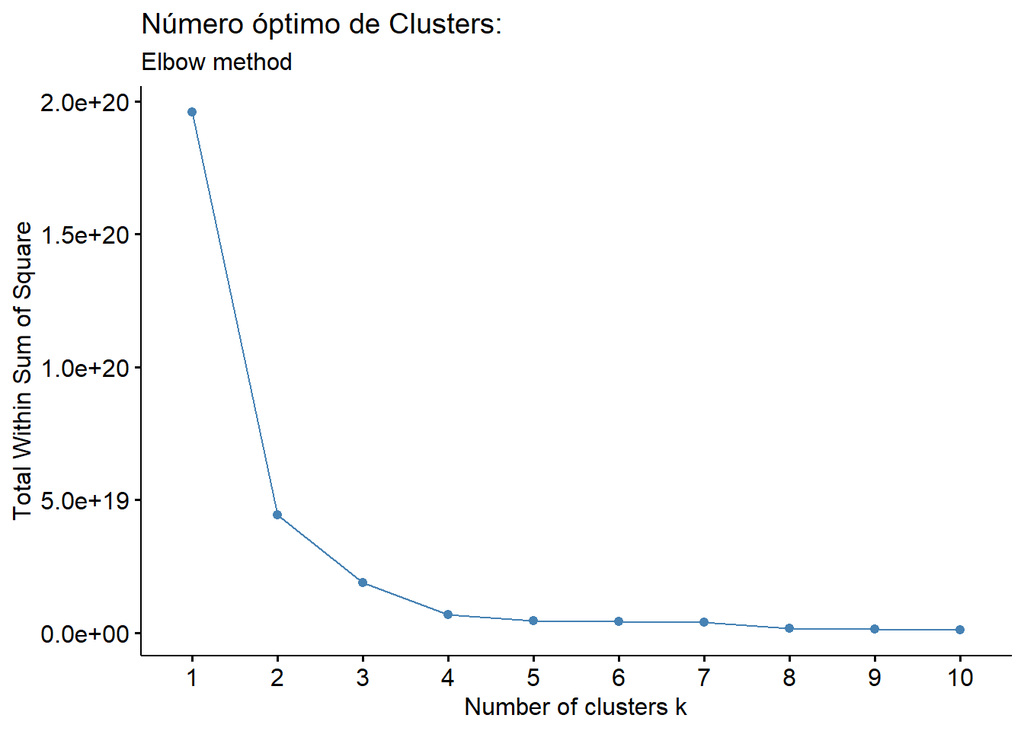

```r
# Ver metricas por metodo del Codo
sil <- silhouette(kmeans_result$cluster, dist(df))

fviz_nbclust(df, kmeans, method = "wss") +
  labs(title = "Número óptimo de Clusters:", subtitle = "Elbow method")
```

## cantidad de sujetos por cluster: Más de la mitad de los sujetos están en el cluster 1.

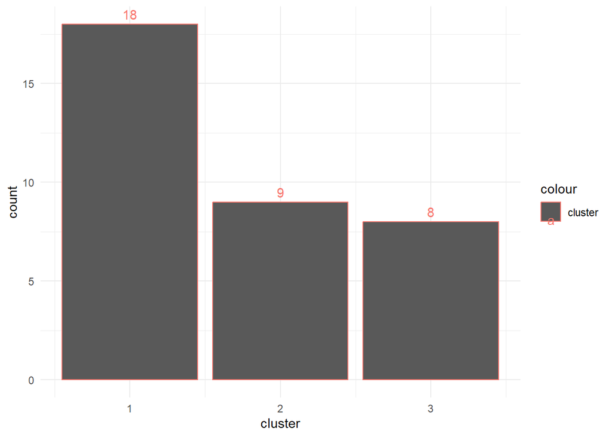

```r
ggplot(df, aes(x=cluster, color = "cluster")) + geom_bar() +

  geom_text(stat = 'count', aes(label = ..count..), vjust = -0.5) +
  theme_minimal()
```

```r
df_1 <- df_actividad_x_id %>%
  mutate(across(c(MinutosMuyActivo, MinutosPocaAct, MinutoSedentario), scale))

set.seed(123)  # Para reproducibilidad
kmeans_result2 <- kmeans(df_1  %>% select(MinutosMuyActivo, MinutosPocaAct, MinutoSedentario), centers = 3) #Cambia '3' por el número de clusters deseado

df_1$cluster <- kmeans_result2$cluster
```

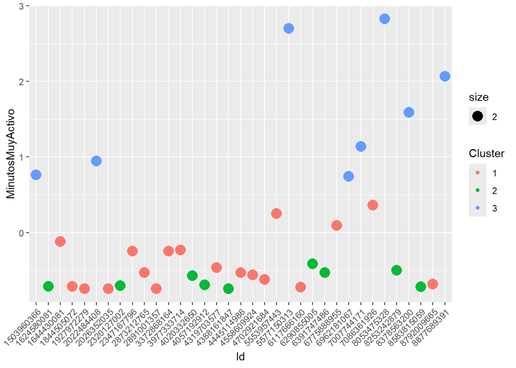

```r
ggplot(df_1, aes(x = Id,y= MinutosMuyActivo, color = as.factor(cluster))) +
  geom_point(aes(size = 2)) +
  labs(color = "Cluster") + theme(axis.text.x = element_text(angle = 45, hjust = 1))
```

## Clusters descripción

Tamaño de los cluster:

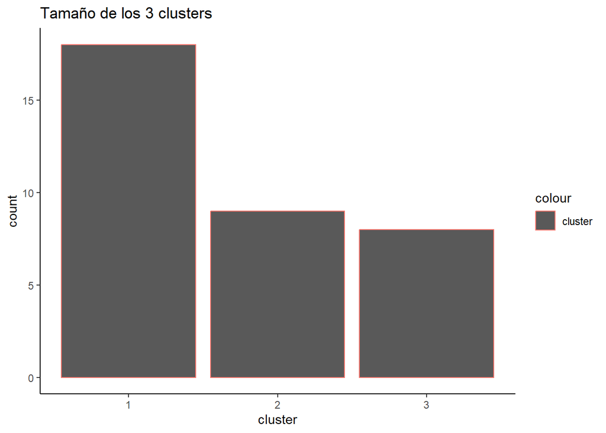

```r
ggplot(df_1, aes(x=cluster, color = "cluster")) + geom_bar() + labs(title = "Tamaño de los 3 clusters") + theme_classic()
```

```r
df_5 <- df %>% select( Id, cluster)
df_actividad_plot <- left_join(df_actividad_x_id, df_5, by = "Id")
names(df_actividad_plot)
```

```
## [1] "Id"               "MinutosMuyActivo" "MinutosPocaAct"   "MinutoSedentario"
## [5] "cluster"
```

Comparacion entre clusters por actividad:

```r
clusters_dif <- df_actividad_plot %>% group_by(., cluster) %>%
  summarise(
    Act_intensa_media = mean(MinutosMuyActivo),
    Act_moderada_media = mean(MinutosPocaAct),
    Act_sedentaria_media = mean(MinutoSedentario)
)

clusters_dif
```

```
## # A tibble: 3 × 4
##   cluster Act_intensa_media Act_moderada_media Act_sedentaria_media
##     <int>             <dbl>              <dbl>                <dbl>
## 1       1              8.17              202.                  896.
## 2       2              2.93               76.7                1280.
## 3       3             55.6               217.                  873.
```

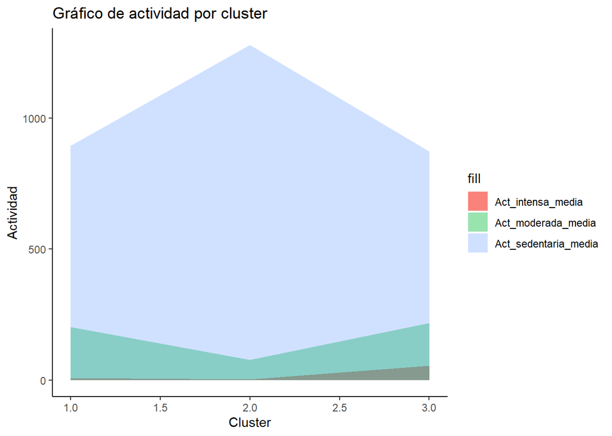

```r
# Creas un gráfico de área con las 3 columnas
ggplot(clusters_dif, aes(x = cluster)) +
  geom_area(aes(y = Act_intensa_media, fill = "Act_intensa_media"), alpha = 0.9, position = "stack") +
  geom_area(aes(y = Act_moderada_media, fill = "Act_moderada_media"), alpha = 0.4, position = "stack") +
  geom_area(aes(y = Act_sedentaria_media, fill = "Act_sedentaria_media"), alpha = 0.3, position = "stack") +
  labs(title = "Gráfico de actividad por cluster", x = "Cluster", y = "Actividad") +
  theme_classic()
```

# Conclusiones finales:

- El estudio de FitBit es un buen comienzo pero necesitariamos ampliar la información, la información más confiable es la creada de primera fuente, la que nosotros podemos recabar a partir de nuestros dispositivos con nuestros usuarios, sería bueno desarrollar esa alternativa.
- Se recomienda poner mayor foco en el cluster 1 es el cluster de Mayor cantidad de personas. Este cluster tiene un comportamiento donde mayormente predomina la actividad sedentaria, la actividad intensa es casi nula, la actividad moderada esta dentro del promedio respecto de toda la muestra.